# index

ADG

2024-03-14

# Intro

## Getting Started

Data pulled from Morningstar Direct on March 11, 20243. Files combined using *combine_files.r*. Data in M* filtered:

- Obsolete >= 2018-01-01

33860 rows, 102 columns

Added column *Obsolete* to indicate if share class is in existence or obsolete. I assume a blank *Obsolete..Date* means the share class still exists.

Also added *Inception_Year* and *Obsolete_Year* because these variables are used below.

Data filtered to remove:

- “Load Waived” Share.Class.Type *Fund of funds
- money markets
- Share classes launched and liquidated during the same 18 month period
- Share classes launched after 2023

```r
library(tidyverse) #For Data Analysis
library(lubridate) #For working with dates
library(DT) #For visualizing tables

current <- "2023"
last <- "2022"
five_year <- "2018"

Full <- read_csv("data_combined.csv",
                 guess_max = 20000) %>%
  rename_all(make.names) %>%
  mutate(
    Inception_Year = year(Inception..Date),
    Obsolete_Year = year(Obsolete..Date),
    Obsolete =
      case_when(!is.na(Obsolete..Date) ~ "Obsolete",
                TRUE ~ "Exists"),
    Life_Span = time_length(interval(Inception..Date, Obsolete..Date), "month")
  ) %>%
  filter(
    Share.Class.Type != "Load Waived" |
      is.na(Share.Class.Type),
    Life_Span >= 18 |
      is.na(Obsolete_Year) |
      is.na(Inception_Year),
    Inception_Year < 2024,
    Fund.of..Funds ==  "No",
    US.Category.Group != "Money Market" |
      is.na(US.Category.Group)
)
```

# Overview

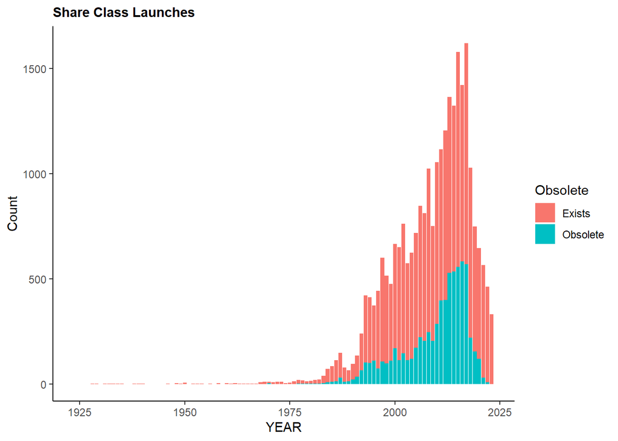

## Net Count

There was a large drop off in launches in 2020 compared to recent years. However it appears rationalization continued at roughly the same levels as recent years.

```r
#A function to count the number of share classes either created or liquidated each year

Year_Count <- function(colz){
 Full %>%
    group_by_at(colz) %>%
    summarise(Count = n(), .groups = "drop") %>%
    arrange(desc(.[[1]]))
    }


inception_year <- Year_Count(colz = c("Inception_Year")) #Tallys share classes by year created
obsolete_year <- Year_Count(colz = c("Obsolete_Year")) #Tallys share classes by year liquidated

merge_type <- Year_Count(colz = c("Obsolete_Year", "Obsolete..Type")) #Tallys share classes by year liquidated and liquidation type


#Counts the net number of share classes created/cut

Net_Count <- full_join(inception_year, obsolete_year, by = c("Inception_Year" = "Obsolete_Year"),
                       suffix = c("_inception", "_obsolete")) %>%
  rename(Year = Inception_Year) %>%
  group_by(Year) %>%
  mutate(Net_Count = sum(Count_inception, -Count_obsolete, na.rm = TRUE))
```

|  | Year | Share_Classes_Launched | Share_Classes_Cut | Net_Count |
| --- | --- | --- | --- | --- |
| 1 | 2023 | 332 | 886 | -554 |
| 2 | 2022 | 463 | 697 | -234 |
| 3 | 2021 | 566 | 998 | -432 |
| 4 | 2020 | 647 | 1425 | -778 |
| 5 | 2019 | 749 | 1315 | -566 |
| 6 | 2018 | 1030 | 1581 | -551 |
| 7 | 2017 | 1621 |  | 1621 |
| 8 | 2016 | 1423 |  | 1423 |
| 9 | 2015 | 1579 |  | 1579 |
| 10 | 2014 | 1324 |  | 1324 |

[output cut: 85 more lines]

## New Funds

The data from Morningstar is at the share class level. This is a method to look at launches at the fund level.

```r
#This looks at when a fund's oldest share class was created
#This assumes that the oldest share class's inception date is equal to the fund's creation date

New_Funds <- Full %>%
  filter(Oldest..Share.Class == "Yes") %>%
  group_by(Inception_Year, Index..Fund) %>%
  summarise(Count = n(), .groups = "drop") %>%
  mutate(
    Pct_Change = round(
      ((Count/lag(Count) - 1) * 100),
      1
    )) %>%
  arrange(desc(Inception_Year))
```

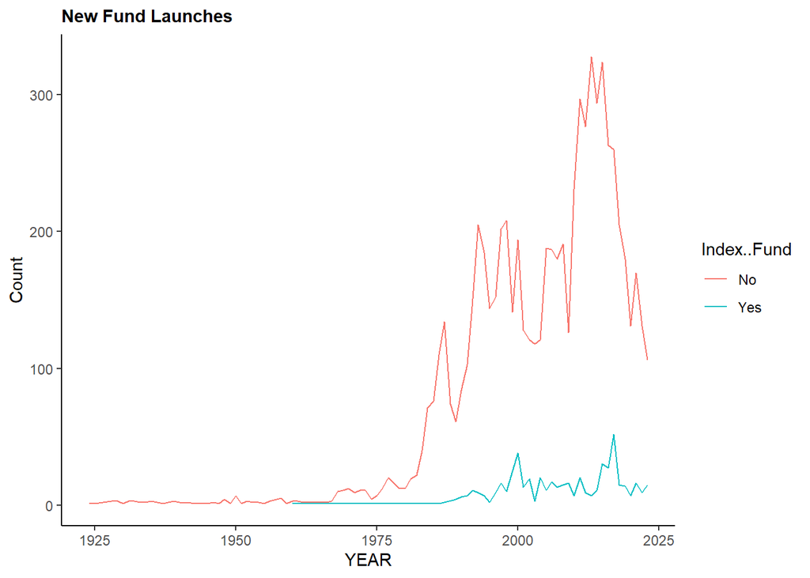

|  | Inception_Year | Active | Passive | total |
| --- | --- | --- | --- | --- |
| 1 | 2023 | 106 | 15 | 121 |
| 2 | 2022 | 131 | 9 | 140 |
| 3 | 2021 | 170 | 16 | 186 |
| 4 | 2020 | 131 | 7 | 138 |
| 5 | 2019 | 180 | 14 | 194 |
| 6 | 2018 | 205 | 15 | 220 |
| 7 | 2017 | 260 | 52 | 312 |
| 8 | 2016 | 263 | 27 | 290 |
| 9 | 2015 | 324 | 30 | 354 |
| 10 | 2014 | 294 | 11 | 305 |

[output cut: 83 more lines]

## New Funds (Alternative)

The method above uses the inception date of the *Oldest..Share.Class* as a proxy for when a fund was created. This method uses *FundId*.

The oldest inception date related to a *FundID* is a proxy for when the fund was created. Or the oldest obsolete date related to a a *FundID* (with no active share classes) is likely when that fund was liquidated/merged.

There were some cases identified in the data where a FundID had no corresponding *Oldest..Share.Class*. This could be an error or signal that a fund’s oldest share class is not captured in the data from Morningstar.

The results for 2020 ended up equal using the method above.

This method shows there were 15,825 funds in 2020 vs 15,677 in 2019 – a change of 148 funds. This method shows there were 15,464 in 2018 – a change of 213 funds.

# Companies

To look at which firms cut or added share classes I first clean up the company names with Branding.Names.Mod.

```r
company_change <- Full %>%
  mutate(
    Branding.Name.Mod =
      case_when(
        grepl("State Street", Branding.Name) ~ "State Street",
        grepl("TIAA", Branding.Name) ~ "TIAA/Nuveen",
        grepl("Nuveen", Branding.Name) ~ "Morgan Stanley",
        grepl("Eaton Vance", Branding.Name) ~ "Morgan Stanley",
        grepl("Calvert", Branding.Name) ~ "Eaton Vance/Calvert",
        grepl("iShares", Branding.Name) ~ "iShares/BlackRock",
        grepl("BlackRock", Branding.Name) ~ "iShares/BlackRock",
        grepl("PowerShares", Branding.Name) ~ "PowerShares/Invesco",
        grepl("Invesco", Branding.Name) ~ "PowerShares/Invesco",
        grepl("DWS$", Branding.Name) ~ "DWS/Xtrackers",
        grepl("Xtrackers", Branding.Name) ~ "DWS/Xtrackers",
        grepl("^Capital Group", Branding.Name) ~ "American Funds",
        Branding.Name %in% c("Harding Loevner", "Third Avenue",
                             "Tweedy, Browner") ~ "AMG",
        Branding.Name == "Oppenheimer" ~ "PowerShares/Invesco",
        Branding.Name == "Wells Fargo" ~ "Allspring",
        Branding.Name %in% "Amundi" ~ "Pioneer Investments",
        TRUE ~ Branding.Name
      ))




    company_level_2018 <- company_change %>%
      filter(Inception_Year <= five_year) %>%
      mutate(
        Count_2018 =
          case_when(
            is.na(Obsolete_Year) ~ "Exists_2018",
            Obsolete_Year <= five_year ~ "Obsolete_2018",
            Obsolete_Year > five_year ~ "Exists_2018",
            TRUE ~ "Other"
      ))

    company_level_2018 <- company_level_2018 %>%
      select(Branding.Name.Mod,
                Name,
                FundId,
                Count_2018) %>%
      group_by(Branding.Name.Mod, Name, Count_2018) %>%
      summarise(Tally_2018 = n()) %>%
      pivot_wider(names_from = Count_2018,
                  values_from = Tally_2018)
      company_level_2023 <- company_change %>%
      filter(Inception_Year <= current) %>%
      mutate(
        Count_2023 =
          case_when(
            is.na(Obsolete_Year) ~ "Exists_2023",
            Obsolete_Year <= current ~ "Obsolete_2023",
            Obsolete_Year > current ~ "Exists_2023",
            TRUE ~ "Other"
      ))

    company_level_2023 <- company_level_2023 %>%
      select(Branding.Name.Mod,
                Name,
                FundId,
                Count_2023) %>%
      group_by(Branding.Name.Mod, Name, Count_2023) %>%
      summarise(Tally_2023 = n()) %>%
      pivot_wider(names_from = Count_2023,
                  values_from = Tally_2023)
    company_level_change <-
      full_join(company_level_2018, company_level_2023)
    company_level_change <- company_level_change %>%
      group_by(Branding.Name.Mod) %>%
      summarise(Exists_2023 = sum(Exists_2023, na.rm = T),
                Exists_2018 = sum(Exists_2018, na.rm = T),
                Change = sum(Exists_2023,-Exists_2018, na.rm = T))



    company_funds <- company_change %>%
      group_by(FundId) %>%
      mutate(
        Newest_ObDate = max(Obsolete_Year),
        Oldest_InDate = min(Inception_Year)
      ) %>%
      group_by(Branding.Name.Mod,
               FundId,
               Newest_ObDate,
               Oldest_InDate) %>%
      summarise() %>%
      mutate(
        Count_2023 =
          case_when(
            is.na(Newest_ObDate) ~ 1,
            Newest_ObDate == current ~ 1,
            Newest_ObDate <= last ~ 0
          ),
        Count_2018 =
          case_when(
            is.na(Newest_ObDate) & Oldest_InDate <= five_year ~ 1,
            Oldest_InDate > five_year | Newest_ObDate <= five_year ~ 0,
            Newest_ObDate > five_year ~ 1
          )
      )
```

```
## 'Newest_ObDate'. You can override using the `.groups` argument.
```

```r
    company_fund_change <- company_funds %>%
      group_by(Branding.Name.Mod) %>%
      summarise(
        Total_2018 = sum(Count_2018, na.rm = T),
        Total_2023 = sum(Count_2023, na.rm = T),
        Difference = sum(Total_2023,-Total_2018, na.rm = T)
      )

    company_count <- function(x, colz) {
      company_change %>%
        group_by_at(colz) %>%
        summarise(Count = n()) %>%
        ungroup() %>%
        arrange(desc(.[[2]]))
    }

    comp_inception <-
      company_count(colz = c("Branding.Name.Mod", "Inception_Year"))
    comp_obsolete <-
      company_count(colz = c("Branding.Name.Mod", "Obsolete_Year"))
    comp_new_funds <-
      company_count(
        colz = c("Branding.Name.Mod", "Inception_Year", "Oldest..Share.Class")
      ) %>%
      filter(Oldest..Share.Class == "Yes")
```

```
## can override using the `.groups` argument.
```

```r
    comp_old_funds <-
      company_count(
        colz = c("Branding.Name.Mod", "Obsolete_Year", "Oldest..Share.Class")
      ) %>%
      filter(Oldest..Share.Class == "Yes")
```

```
## can override using the `.groups` argument.
```

```r
    comp_rank <- function(x) {
      x %>%  filter(.[[2]] == current) %>%
        mutate(Rank = rank(-Count)) %>%
        filter(Rank <= 20) %>%
        arrange(Rank)
    }

    top_cutters <- comp_rank(comp_obsolete)
    top_old_cutters <-  comp_rank(comp_old_funds)

    top_launchers <- comp_rank(comp_inception)
    top_new_launchers <- comp_rank(comp_new_funds)
```

|  | Branding.Name.Mod | Exists_2023 | Exists_2018 | Change |
| --- | --- | --- | --- | --- |
| 1 | 1290 Funds | 21 | 26 | -5 |
| 2 | 13D Activist Fund | 3 | 3 | 0 |
| 3 | 1919 Funds | 9 | 10 | -1 |
| 4 | 361 Capital | 0 | 9 | -9 |
| 5 | AAM | 12 | 15 | -3 |
| 6 | AAMA | 2 | 2 | 0 |
| 7 | ABR Dynamic Funds | 6 | 4 | 2 |
| 8 | AC One | 0 | 1 | -1 |
| 9 | ACR | 2 | 4 | -2 |
| 10 | AEGON | 0 | 0 | 0 |

[output cut: 789 more lines]

## Top Launchers

(Share Class)

|  | Branding.Name.Mod | Inception_Year | Count | Rank |
| --- | --- | --- | --- | --- |
| 1 | Fidelity | 2023 | 23 | 1 |
| 2 | MassMutual | 2023 | 21 | 2 |
| 3 | Voya | 2023 | 15 | 3 |
| 4 | Transamerica | 2023 | 13 | 4.5 |
| 5 | iShares/BlackRock | 2023 | 13 | 4.5 |
| 6 | Aristotle Funds | 2023 | 12 | 6 |
| 7 | New York Life | 2023 | 11 | 7 |
| 8 | WisdomTree | 2023 | 10 | 8 |
| 9 | Morgan Stanley | 2023 | 9 | 9.5 |
| 10 | Thornburg | 2023 | 9 | 9.5 |

[output cut: 9 more lines]

## Top New Fund Launchers

(Oldest Share Class)

|  | Branding.Name.Mod | Inception_Year | Oldest..Share.Class | Count | Rank |
| --- | --- | --- | --- | --- | --- |
| 1 | Fidelity | 2023 | Yes | 12 | 1 |
| 2 | Voya | 2023 | Yes | 11 | 2 |
| 3 | WisdomTree | 2023 | Yes | 10 | 3 |
| 4 | iShares/BlackRock | 2023 | Yes | 5 | 4 |
| 5 | Column | 2023 | Yes | 4 | 5.5 |
| 6 | Transamerica | 2023 | Yes | 4 | 5.5 |
| 7 | John Hancock | 2023 | Yes | 3 | 7.5 |
| 8 | Thornburg | 2023 | Yes | 3 | 7.5 |
| 9 | Advisors Preferred | 2023 | Yes | 2 | 12.5 |
| 10 | Calamos | 2023 | Yes | 2 | 12.5 |

[output cut: 6 more lines]

## Top Cutters

(Share Class)

|  | Branding.Name.Mod | Obsolete_Year | Count | Rank |
| --- | --- | --- | --- | --- |
| 1 | Macquarie | 2023 | 67 | 1 |
| 2 | PowerShares/Invesco | 2023 | 55 | 2 |
| 3 | Columbia Threadneedle | 2023 | 46 | 3 |
| 4 | Franklin Templeton | 2023 | 39 | 4 |
| 5 | Fidelity | 2023 | 31 | 5 |
| 6 | Allspring | 2023 | 30 | 6.5 |
| 7 | Aristotle Funds | 2023 | 30 | 6.5 |
| 8 | JPMorgan | 2023 | 29 | 8 |
| 9 | Voya | 2023 | 25 | 9 |
| 10 | Federated Hermes | 2023 | 23 | 10 |

[output cut: 11 more lines]

## Top Fund Cutters

(Oldest Share Class)

|  | Branding.Name.Mod | Obsolete_Year | Oldest..Share.Class | Count | Rank |
| --- | --- | --- | --- | --- | --- |
| 1 | Aristotle Funds | 2023 | Yes | 17 | 1 |
| 2 | Macquarie | 2023 | Yes | 14 | 2 |
| 3 | Allspring | 2023 | Yes | 12 | 3.5 |
| 4 | Fidelity | 2023 | Yes | 12 | 3.5 |
| 5 | PowerShares/Invesco | 2023 | Yes | 10 | 5 |
| 6 | JPMorgan | 2023 | Yes | 8 | 6 |
| 7 | Columbia Threadneedle | 2023 | Yes | 7 | 7.5 |
| 8 | iShares/BlackRock | 2023 | Yes | 7 | 7.5 |
| 9 | Franklin Templeton | 2023 | Yes | 6 | 9.5 |
| 10 | Virtus | 2023 | Yes | 6 | 9.5 |

[output cut: 11 more lines]

# Share Class Overview

##Launches

```r
simp_count <- function(x, colz){
  Full %>%
    group_by_at(colz) %>%
    count(name = "Count")
  }
```

From Morningstar Direct

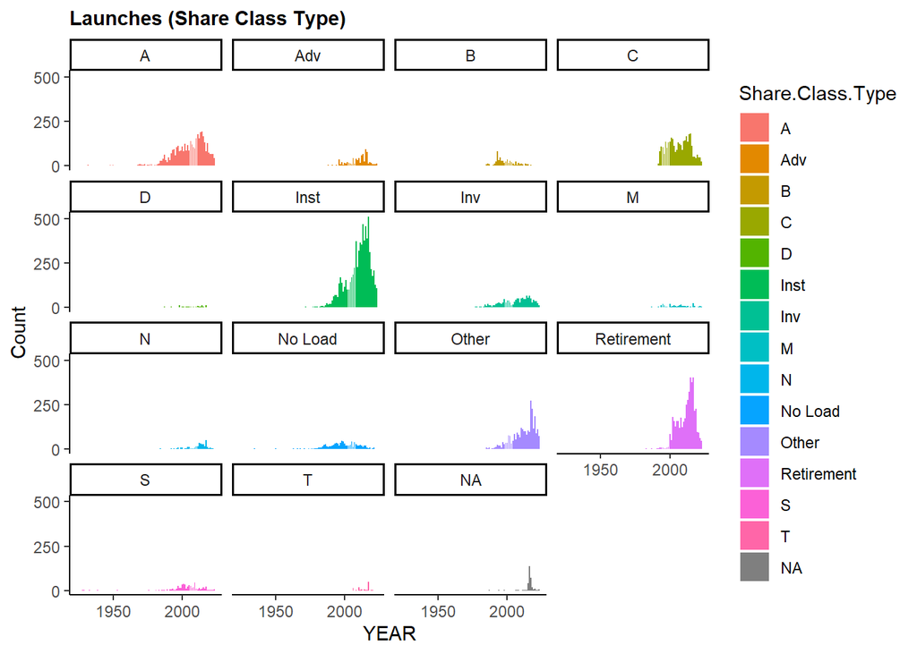

## 2023 Launches

|  | Inception_Year | Share.Class.Type | Count |
| --- | --- | --- | --- |
| 1 | 2023 | Inst | 106 |
| 2 | 2023 | Other | 71 |
| 3 | 2023 | Retirement | 46 |
| 4 | 2023 | A | 44 |
| 5 | 2023 | C | 24 |
| 6 | 2023 | Adv | 14 |
| 7 | 2023 | Inv | 12 |
| 8 | 2023 | S | 6 |
| 9 | 2023 |  | 5 |
| 10 | 2023 | M | 3 |

[output cut: 1 more lines]

##Liquidations

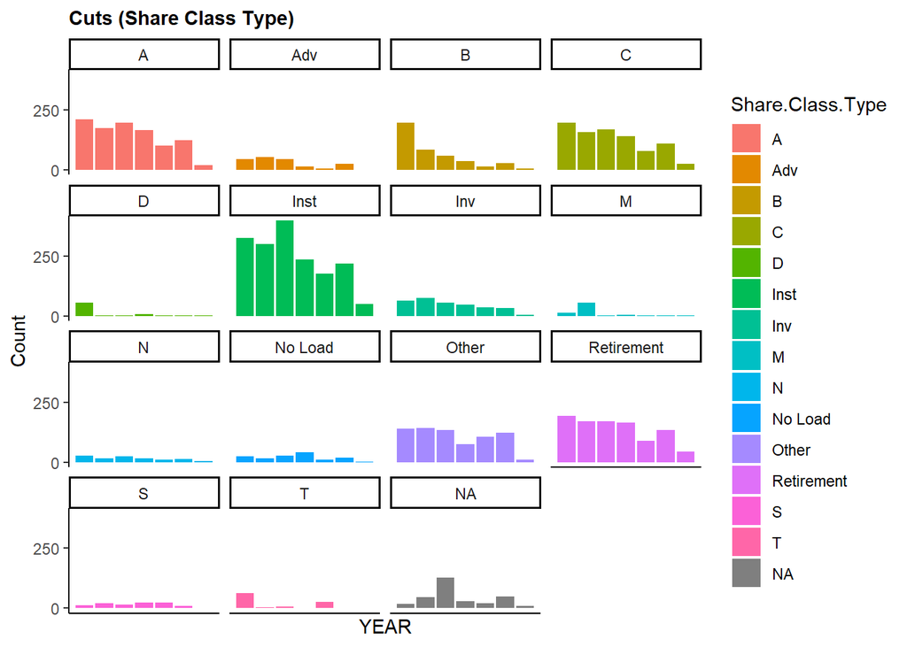

## 2023 Liquidations

|  | Obsolete_Year | Share.Class.Type | Count |
| --- | --- | --- | --- |
| 1 | 2023 | Inst | 217 |
| 2 | 2023 | Retirement | 134 |
| 3 | 2023 | A | 124 |
| 4 | 2023 | Other | 122 |
| 5 | 2023 | C | 110 |
| 6 | 2023 |  | 49 |
| 7 | 2023 | Inv | 32 |
| 8 | 2023 | B | 27 |
| 9 | 2023 | Adv | 24 |
| 10 | 2023 | No Load | 18 |

[output cut: 4 more lines]

## Other/NA

This is an attempt to determine the share class type in cases where Morningstar has the share classs listed as other or NA.

## Changes

|  | Name | EXTRACT | New | Revision | Match |
| --- | --- | --- | --- | --- | --- |
| 1 | Columbia Dividend Opportunity Inst2 | Inst2 | Inst2 | Instlnst2 | True |
| 2 | Columbia Dividend Opportunity Inst3 | Inst3 | Inst3 | Instlnst3 | True |
| 3 | Columbia Dividend Opportunity R | R | R | R | True |
| 4 | Columbia Emerging Markets A | A | A | A | True |
| 5 | Columbia Emerging Markets Adv | Adv | Adv | Advisor | True |
| 6 | Columbia Emerging Markets Bond A | A | A | A | True |
| 7 | Columbia Emerging Markets Bond Adv | Adv | Adv | Advisor | True |
| 8 | Columbia Emerging Markets Bond C | C | C | C | True |
| 9 | Columbia Emerging Markets Bond Inst | Inst | Inst | Instlnstl | True |
| 10 | Columbia Emerging Markets Bond Inst2 | Inst2 | Inst2 | Instlnst2 | True |

[output cut: 26515 more lines]